# paper2 E2

Alex Holcombe

November 27, 2017

Import the dataframe.

```
  trial target condition subject respSP allLetterOrientations targetSP
1     1      1         1      CB      6                     0        6
2     2      1         2      CB      6                     0        6
3     3      1         2      CB      5                     0        5
4     4      1         1      CB      6                     1        6
5     5      1         2      CB      6                     0        6
6     6      1         2      CB     15                     1        7
  allTargetOrientations resp allResponseOrientations   allRTs SPE
1                     0    6                       0 2.502437   0
2                     1   16                       1 4.536533   0
3                     1   11                       1 4.259832   0
4                     0    9                       0 2.113052   0
5                     1   11                       0 9.702079   0
6                     1   16                       0 6.756404   8
```

Fit mixture model with R (if fitting not previously done and cached), print first several parameter estimates:

```
# A tibble: 6 x 8
# Groups:   subject, condition, target [6]
  subject condition target  efficacy   latency precision      val warnings
    <chr>     <dbl>  <int>     <dbl>     <dbl>     <dbl>    <dbl>   <fctr>
1      CB         1      1 0.8192165 0.3812707 0.5721594 167.0096     None
2      CB         1      2 0.4628627 0.5481285 0.1955467 242.3176     None
3      CB         2      1 0.7945427 0.6188718 0.3852985 155.7369     None
4      CB         2      2 0.4365098 0.7048584 0.5443965 255.3719     None
5      CL         1      1 0.3380332 0.1881993 0.4406164 259.8876     None
6      CL         1      2 0.7543734 0.2034749 0.3824136 164.6744     None
```

Plot the histogram and fit for one subject*condition.

- yellow = guessing component
- light blue = Gaussian component
- green = sum of the guessing and Gaussian components. In other words, the histogram heights predicted by the model
- dark blue = continuous Gaussian. This helps get a sense of the effect of discretising the Gaussian. For instance, it’s possible for the Gaussian peak to rise high above the bars and still fit the discrete bins, suggesting undesirably high estimates of the efficacy (likely accompanied by an undesirably low precision)

For likelihood, lower neg log likelihood means better fit.

```
[1] "/Users/alexh/Documents/attention_tempresltn/RSVPdataAnalysis/MixtureModelRSVP"
```

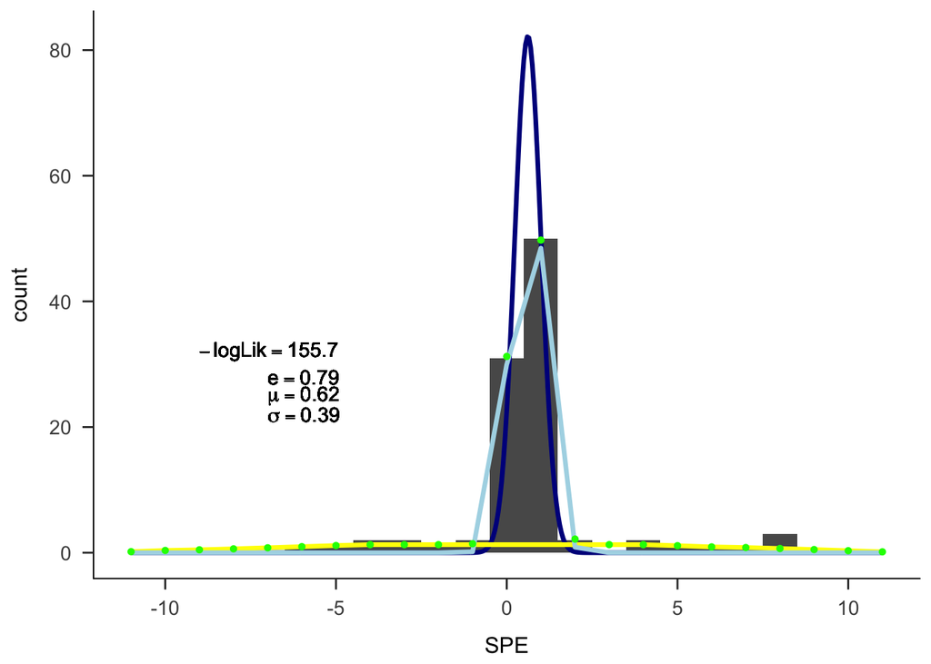

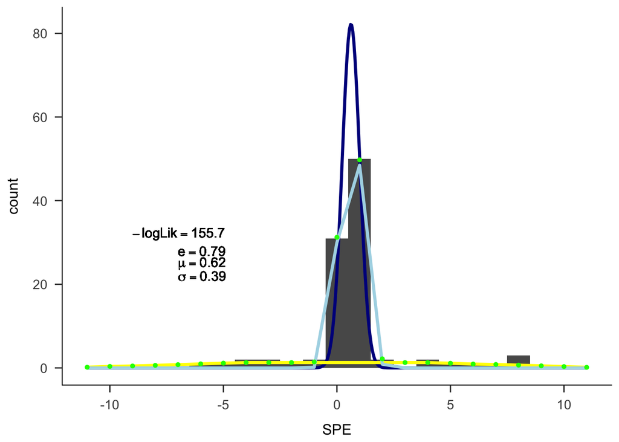

Plot all data. First column is left stream. Second column is right stream. Each subject gets a pair of rows, “1” for upright letters, “2” for backwards letters?

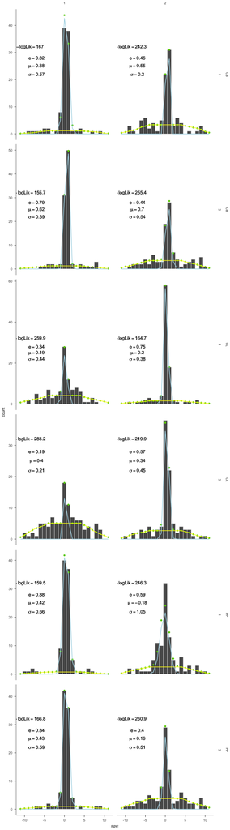